Business Analysis: Tweet Count vs Tesla Stock Price Change

# Research question

`How much does Elon Musk's number of tweets per day affect Tesla's stock price change?`

# Investigation Overview

For stock investors, especially day-traders, the rate of change in stock prices is an important factor for short-term planning. Even if the degree of change is small, it can be usefully reflected in the stock price prediction model if the variable has statistically convincing evidence.

We will gather two separate datasets, one for tweets and the other one for the stock price, and then combine those two. The period of the original dataset ranges between 2010 and 2021, and moving averages per lengths. With the datasets, we will statistically analyze them with a simple linear regression; `Stock price change (%) = β0 + β1*tweet`. Finally, we will interpret the output from different points of view.

As a disclaimer, our major question, "How much does Elon Musk's number of tweets per day affect Tesla's stock price change?" may have several different approaches to get the most trustful answer depending on each perspective.

# Data description

The original dataset includes stock price and Elon’s tweets records between January 2010 and March 2021. Elon started his first tweet in 2010 and still using Twitter as the major social media. Because there was no tweeting until January 2012 after his first tweet in January 2010, we include datasets from January 2012 to March 2021.

- Qualitative variable: date (‘yyyy-mm-dd’)
- Quantitative variable: price change (%), Tweet count per day (integer)

# Data source

We referred to two sources - Tweet and stock price. Tweet dataset comes from ‘Kaggle.com’ (URL: https://www.kaggle.com/ayhmrba/elon-musk-tweets-2010-2021), and stock price dataset is based on ‘Nasdaq.com’ (URL: https://www.nasdaq.com/)

# Data gathering

## Tweet

We will use open source from Kaggle (https://www.kaggle.com/ayhmrba/elon-musk-tweets-2010-2021) which contain the entire tweets since 2010.

```python
# import requried libraries

import pandas as pd
import yfinance as yf
import numpy as np
import seaborn as sb
import requests
import io
import datetime
import statsmodels.api as sm
import matplotlib.pyplot as plt
%matplotlib inline

%matplotlib inline
# To get the same result from different setup
```

```python
# download csv files from Kaggle and store those in the same folder where this file is located.
# create a new folder inside of the folder

for year in range(2010, 2022, 1):
    nexty = year+1
    if year == 2021:
        pass
    else:
        print(year, nexty)
        df = pd.concat(map(pd.read_csv, ['./tweet_elon/%d.csv' %year, './tweet_elon/%d.csv' %nexty]), ignore_index=True)
```

```
2010 2011
2011 2012
2012 2013
2013 2014
2014 2015
2015 2016
2016 2017
2017 2018
2018 2019
2019 2020
2020 2021
```

```python
# df.to_csv('tweets.csv')
```

```python
df.head()
```

|  | Unnamed: 0 | id | conversation_id | created_at | date | timezone | place | tweet | language | hashtags | ... | geo | source | user_rt_id | user_rt | retweet_id | reply_to | retweet_date | translate | trans_src | trans_dest |
| --- | --- | --- | --- | --- | --- | --- | --- | --- | --- | --- | --- | --- | --- | --- | --- | --- | --- | --- | --- | --- | --- |
| 0 | 0 | 1343644462036086785 | 1343320495127633920 | 1.609185e+12 | 2020-12-28 19:46:18 | 0 | NaN | Entertainment will be critical when cars drive... | en | [] | ... | NaN | NaN | NaN | NaN | NaN | [] | NaN | NaN | NaN | NaN |
| 1 | 1 | 1343619610617077760 | 1343386617294295040 | 1.609179e+12 | 2020-12-28 18:07:33 | 0 | NaN | @kimpaquette Just meeting with Larry Ellison t... | en | [] | ... | NaN | NaN | NaN | NaN | NaN | [{'screen_name': 'kimpaquette', 'name': 'Kim P... | NaN | NaN | NaN | NaN |
| 2 | 2 | 1343608616960491521 | 1343576442722893825 | 1.609176e+12 | 2020-12-28 17:23:51 | 0 | NaN | @richierichhhhh_ Absolutely | en | [] | ... | NaN | NaN | NaN | NaN | NaN | [{'screen_name': 'richierichhhhh_', 'name': 'R... | NaN | NaN | NaN | NaN |
| 3 | 3 | 1343608530998153222 | 1343320495127633920 | 1.609176e+12 | 2020-12-28 17:23:31 | 0 | NaN | What should Tesla do with in-car gaming in an ... | en | [] | ... | NaN | NaN | NaN | NaN | NaN | [] | NaN | NaN | NaN | NaN |
| 4 | 4 | 1343431408052662273 | 1343043963096326147 | 1.609134e+12 | 2020-12-28 05:39:42 | 0 | NaN | @PPathole @WSJ Absolutely | en | [] | ... | NaN | NaN | NaN | NaN | NaN | [{'screen_name': 'PPathole', 'name': 'Pranay P... | NaN | NaN | NaN | NaN |

5 rows × 39 columns

```python
# only get required columns

dft = df[['date', 'tweet']]
dft.head()
```

|  | date | tweet |
| --- | --- | --- |
| 0 | 2020-12-28 19:46:18 | Entertainment will be critical when cars drive... |
| 1 | 2020-12-28 18:07:33 | @kimpaquette Just meeting with Larry Ellison t... |
| 2 | 2020-12-28 17:23:51 | @richierichhhhh_ Absolutely |
| 3 | 2020-12-28 17:23:31 | What should Tesla do with in-car gaming in an ... |
| 4 | 2020-12-28 05:39:42 | @PPathole @WSJ Absolutely |

```python
dft.shape
```

```
(24056, 2)
```

```python
# import requried libraries

import pandas as pd
import yfinance as yf
import numpy as np
import matplotlib.pyplot as plt
import seaborn as sb
import requests
import io
import datetime
import statsmodels.api as sm

%matplotlib inline
# To get the same result from different setup
```

```python
# adjust the date as yyyy-mm-dd

dft['date'] = pd.to_datetime(dft['date']).dt.date
dft.head()
```

|  | date | tweet |
| --- | --- | --- |
| 0 | 2020-12-28 | Entertainment will be critical when cars drive... |
| 1 | 2020-12-28 | @kimpaquette Just meeting with Larry Ellison t... |
| 2 | 2020-12-28 | @richierichhhhh_ Absolutely |
| 3 | 2020-12-28 | What should Tesla do with in-car gaming in an ... |
| 4 | 2020-12-28 | @PPathole @WSJ Absolutely |

```python
# check the max. number of tweets per a day

dft.date.value_counts()
```

```
2020-04-16    112
2018-06-17     98
2017-03-24     98
2019-12-30     94
2020-05-15     88
             ...
2021-01-05      1
2021-02-02      1
2021-01-03      1
2021-01-01      1
2021-03-16      1
Name: date, Length: 2005, dtype: int64
```

```python
tweet = dft.groupby('date').count()
```

## StockPrice

We will use a library from Yahoo finance https://towardsdatascience.com/downloading-historical-stock-prices-in-python-93f85f059c1f), which contains the entire Nasdaq stock record.

```python
url="https://pkgstore.datahub.io/core/nasdaq-listings/nasdaq-listed_csv/data/7665719fb51081ba0bd834fde71ce822/nasdaq-listed_csv.csv"

s = requests.get(url).content
companies = pd.read_csv(io.StringIO(s.decode('utf-8')))
companies.head()
```

|  | Symbol | Company Name | Security Name | Market Category | Test Issue | Financial Status | Round Lot Size |
| --- | --- | --- | --- | --- | --- | --- | --- |
| 0 | AAIT | iShares MSCI All Country Asia Information Tech... | iShares MSCI All Country Asia Information Tech... | G | N | N | 100.0 |
| 1 | AAL | American Airlines Group, Inc. | American Airlines Group, Inc. - Common Stock | Q | N | N | 100.0 |
| 2 | AAME | Atlantic American Corporation | Atlantic American Corporation - Common Stock | G | N | N | 100.0 |
| 3 | AAOI | Applied Optoelectronics, Inc. | Applied Optoelectronics, Inc. - Common Stock | G | N | N | 100.0 |
| 4 | AAON | AAON, Inc. | AAON, Inc. - Common Stock | Q | N | N | 100.0 |

```python
# companies.to_csv('companies.csv')
```

```python
Symbols = companies['Symbol'].tolist()
```

```python
'TSLA' in Symbols
```

```
True
```

Select stock price data until 3/22/2021 to match with tweet data

```python
start = datetime.datetime(2010,1,1)
end = datetime.datetime(2021,3,22)
```

```python
# create empty dataframe to get only TSLA
stock_final = pd.DataFrame()

try:
    # download the stock price
    stock = []
    stock = yf.download('TSLA',start=start, end=end, progress=False)

    # append the individual stock prices
    if len(stock) == 0:
        None
    else:
        stock['Name']='TSLA'
        stock_final = stock_final.append(stock,sort=False)
except Exception:
    None
```

```python
stock_final.head()
```

| Date | Open | High | Low | Close | Adj Close | Volume | Name |
| --- | --- | --- | --- | --- | --- | --- | --- |
| 2010-06-29 | 3.800 | 5.000 | 3.508 | 4.778 | 4.778 | 93831500 | TSLA |
| 2010-06-30 | 5.158 | 6.084 | 4.660 | 4.766 | 4.766 | 85935500 | TSLA |
| 2010-07-01 | 5.000 | 5.184 | 4.054 | 4.392 | 4.392 | 41094000 | TSLA |
| 2010-07-02 | 4.600 | 4.620 | 3.742 | 3.840 | 3.840 | 25699000 | TSLA |
| 2010-07-06 | 4.000 | 4.000 | 3.166 | 3.222 | 3.222 | 34334500 | TSLA |

```python
stock_final.shape
```

```
(2700, 7)
```

```python
# get required columns
# change each column name as lowercase to sort for ease
# reset index and data column type

stock = stock_final[['Close']]
stock.reset_index(inplace = True)
stock = stock.rename(columns = {'Date':'date', 'Close':'price', 'Volume':'volume'})
stock['date'] = pd.to_datetime(stock['date']).dt.date
stock.head()
```

|  | date | price |
| --- | --- | --- |
| 0 | 2010-06-29 | 4.778 |
| 1 | 2010-06-30 | 4.766 |
| 2 | 2010-07-01 | 4.392 |
| 3 | 2010-07-02 | 3.840 |
| 4 | 2010-07-06 | 3.222 |

Now, we are creating new columns for `price change`.

> *Percentage Change Formula = `(New Value - Original Value) / Original Value x 100`*

```python
price_change = []
for i in range(0,2699,1):
    price_change.append(np.absolute((stock.price[i+1]-stock.price[i])/stock.price[i])*100)
```

```python
stock = stock.iloc[1:]   # because the calculation composes pairs
```

```python
stock['price_change'] = price_change
```

```python
stock.head()
```

|  | date | price | price_change |
| --- | --- | --- | --- |
| 1 | 2010-06-30 | 4.766 | 0.251153 |
| 2 | 2010-07-01 | 4.392 | 7.847243 |
| 3 | 2010-07-02 | 3.840 | 12.568312 |
| 4 | 2010-07-06 | 3.222 | 16.093751 |
| 5 | 2010-07-07 | 3.160 | 1.924264 |

```python
stock.shape
```

```
(2699, 3)
```

## Tweet+StockPrice

Tweet + StockPrice = `df`

Because stock data contains more lines than tweet data, we will merge tweet data based on stock data, which triggers Null values in some of the combined datasets. Null means no tweet on the day.

```python
# Based on Stock data. (how = 'left')
# We do left join based on Stock data because the number of tweets include Null values, which means no tweet recorded on that day.

df = stock.merge(tweet, left_on = 'date', right_on = 'date', how = 'left')
df = df.fillna(0)
df.tail(5)
```

|  | date | price | price_change | tweet |
| --- | --- | --- | --- | --- |
| 2694 | 2021-03-15 | 707.940002 | 2.048351 | 4.0 |
| 2695 | 2021-03-16 | 676.880005 | 4.387377 | 1.0 |
| 2696 | 2021-03-17 | 701.809998 | 3.683074 | 3.0 |
| 2697 | 2021-03-18 | 653.159973 | 6.932079 | 7.0 |
| 2698 | 2021-03-19 | 654.869995 | 0.261808 | 11.0 |

```python
df.info()
```

```
<class 'pandas.core.frame.DataFrame'>
Int64Index: 2699 entries, 0 to 2698
Data columns (total 4 columns):
 #   Column        Non-Null Count  Dtype
---  ------        --------------  -----
 0   date          2699 non-null   object
 1   price         2699 non-null   float64
 2   price_change  2699 non-null   float64
 3   tweet         2699 non-null   float64
dtypes: float64(3), object(1)
memory usage: 105.4+ KB
```

```python
# exclude the first half year becase of NaN for tweet during the period

df = df[381:]
df.head(5)
```

|  | date | price | price_change | tweet |
| --- | --- | --- | --- | --- |
| 381 | 2012-01-03 | 5.616 | 1.680667 | 6.0 |
| 382 | 2012-01-04 | 5.542 | 1.317670 | 0.0 |
| 383 | 2012-01-05 | 5.424 | 2.129196 | 0.0 |
| 384 | 2012-01-06 | 5.382 | 0.774333 | 6.0 |
| 385 | 2012-01-09 | 5.450 | 1.263468 | 0.0 |

# Data Cleaning - outliers

## tweet

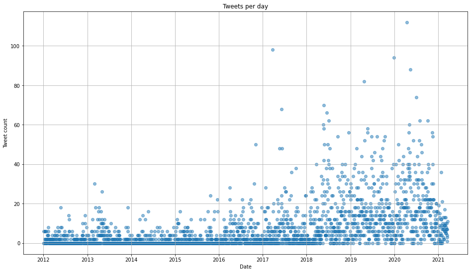

```python
plt.figure(figsize = (16,9))

plt.scatter(data = df, x = 'date', y = 'tweet', alpha = 0.5)
plt.title('Tweets per day')
plt.xlabel('Date')
plt.ylabel('Tweet count')
plt.grid(axis='x')
plt.grid(axis='y')
```

```python
r = np.percentile(df.tweet, 99)
r
```

```
54.0
```

We set outlies which exceed 99 percentile, or 54 tweets a day.

```python
df = df[df.tweet < r]
df.tweet.max()
```

```
52.0
```

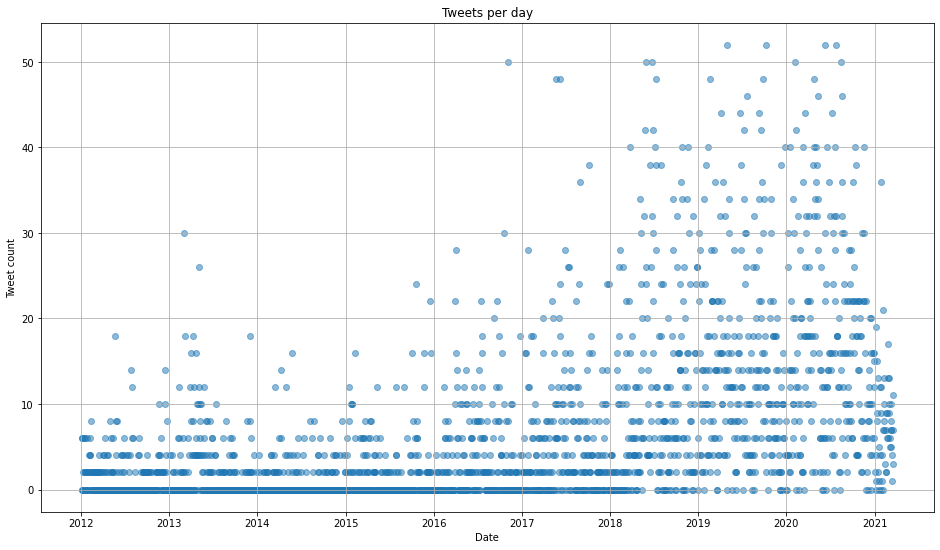

```python
plt.figure(figsize = (16,9))

plt.scatter(data = df, x = 'date', y = 'tweet', alpha = 0.5)
plt.title('Tweets per day')
plt.xlabel('Date')
plt.ylabel('Tweet count')
plt.grid(axis='x')
plt.grid(axis='y')
```

## price_change

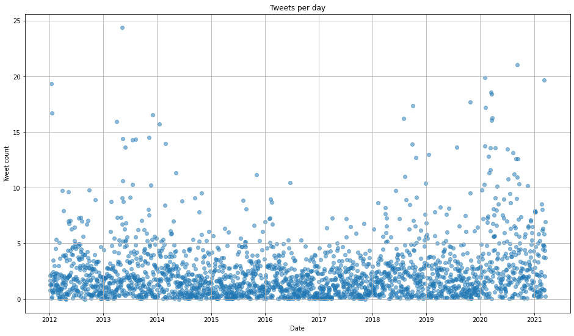

```python
plt.figure(figsize = (16,9))

plt.scatter(data = df, x = 'date', y = 'price_change', alpha = 0.5)
plt.title('Tweets per day')
plt.xlabel('Date')
plt.ylabel('Tweet count')
plt.grid(axis='x')
plt.grid(axis='y')
```

```python
r = np.percentile(df.price_change, 99.9)
r
```

```
19.820796495597587
```

```python
df = df[df.price_change < r]
df.price_change.max()
```

```
19.641210850771536
```

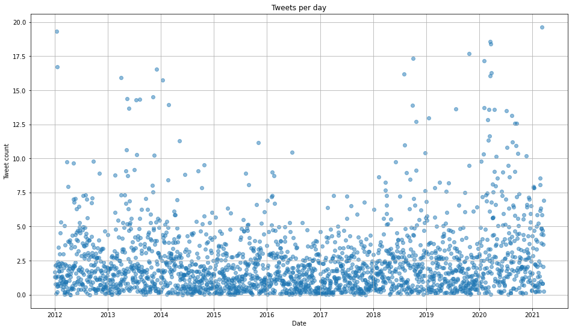

```python
plt.figure(figsize = (16,9))

plt.scatter(data = df, x = 'date', y = 'price_change', alpha = 0.5)
plt.title('Tweets per day')
plt.xlabel('Date')
plt.ylabel('Tweet count')
plt.grid(axis='x')
plt.grid(axis='y')
```

## Histogram

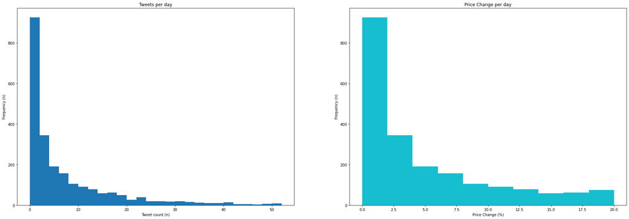

```python
plt.figure(figsize = (30,10))

plt.subplot(1,2,1)

bins = np.arange(0, df.tweet.max()+1, 2)
plt.hist(data = df, x = 'tweet', bins = bins, color = sb.color_palette()[0]);
plt.title('Tweets per day')
plt.xlabel('Tweet count (n)')
plt.ylabel('Frequency (n)')

plt.subplot(1,2,2)
bins = np.arange(0, df.price_change.max()+1, 2)
plt.hist(data = df, x = 'tweet', bins = bins, color = sb.color_palette()[9]);
plt.title('Price Change per day')
plt.xlabel('Price Change (%)')
plt.ylabel('Frequency (n)')

plt.show()
```

# Statistical analysis

**Common moving average lengths are `10`, `20`, `50`, `100` and `200`.**

> *reference: https://www.investopedia.com/articles/active-trading/052014/how-use-moving-average-buy-stocks.asp*

## `10-day` moving average

```python
mvp = 10
i = 0

mavg10 = pd.DataFrame()

mv_pchange = np.array(df.price_change)
price_change_mv = []
for i in range(len(mv_pchange)-mvp+1):
    price_change_mv.append(np.average(mv_pchange[i:mvp+i]))
    i+=1
mavg10['price_change'] = pd.DataFrame(price_change_mv)

mv_tweet = np.array(df.tweet)
tweet_mv = []
for i in range(len(mv_tweet)-mvp+1):
    tweet_mv.append(np.average(mv_tweet[i:mvp+i]))
    i+=1
mavg10['tweet'] = pd.DataFrame(tweet_mv)
```

```python
print(mavg10.describe())
```

```
       price_change        tweet
count   2281.000000  2281.000000
mean       2.367163     6.459097
std        1.135270     6.578821
min        0.524296     0.000000
25%        1.586211     1.400000
50%        2.071912     3.600000
75%        2.837720    10.200000
max        9.511406    32.800000
```

```python
print(mavg10.corr())
```

```
              price_change     tweet
price_change      1.000000  0.347522
tweet             0.347522  1.000000
```

```python
mavg10['intercept'] = 1
lm = sm.OLS(mavg10['price_change'], mavg10[['intercept', 'tweet']])
result = lm.fit()
result.summary()
```

OLS Regression Results

| Dep. Variable: | price_change | R-squared: | 0.121 |
| --- | --- | --- | --- |
| Model: | OLS | Adj. R-squared: | 0.120 |
| Method: | Least Squares | F-statistic: | 313.0 |
| Date: | Tue, 14 Dec 2021 | Prob (F-statistic): | 9.65e-66 |
| Time: | 16:02:36 | Log-Likelihood: | -3378.7 |
| No. Observations: | 2281 | AIC: | 6761. |
| Df Residuals: | 2279 | BIC: | 6773. |
| Df Model: | 1 |  |  |
| Covariance Type: | nonrobust |  |  |

|  | coef | std err | t | P>\|t\| | [0.025 | 0.975] |
| --- | --- | --- | --- | --- | --- | --- |
| intercept | 1.9798 | 0.031 | 63.362 | 0.000 | 1.919 | 2.041 |
| tweet | 0.0600 | 0.003 | 17.693 | 0.000 | 0.053 | 0.067 |

| Omnibus: | 567.715 | Durbin-Watson: | 0.100 |
| --- | --- | --- | --- |
| Prob(Omnibus): | 0.000 | Jarque-Bera (JB): | 1495.472 |
| Skew: | 1.317 | Prob(JB): | 0.00 |
| Kurtosis: | 5.965 | Cond. No. | 13.0 |

Notes:  
[1] Standard Errors assume that the covariance matrix of the errors is correctly specified.

## `20-day` moving average

```python
mvp = 20
i = 0

mavg20 = pd.DataFrame()

mv_pchange = np.array(df.price_change)
price_change_mv = []
for i in range(len(mv_pchange)-mvp+1):
    price_change_mv.append(np.average(mv_pchange[i:mvp+i]))
    i+=1
mavg20['price_change'] = pd.DataFrame(price_change_mv)

mv_tweet = np.array(df.tweet)
tweet_mv = []
for i in range(len(mv_tweet)-mvp+1):
    tweet_mv.append(np.average(mv_tweet[i:mvp+i]))
    i+=1
mavg20['tweet'] = pd.DataFrame(tweet_mv)
```

```python
np.average(mv_pchange[1:10])
```

```
5.018572774796838
```

```python
print(mavg20.describe())
```

```
       price_change        tweet
count   2271.000000  2271.000000
mean       2.356078     6.465918
std        0.974178     6.238348
min        0.736068     0.100000
25%        1.688797     1.500000
50%        2.117926     3.600000
75%        2.799763    10.400000
max        7.466539    27.300000
```

```python
print(mavg20.corr())
```

```
              price_change     tweet
price_change      1.000000  0.413212
tweet             0.413212  1.000000
```

```python
mavg20['intercept'] = 1
lm = sm.OLS(mavg20['price_change'], mavg20[['intercept', 'tweet']])
result = lm.fit()
result.summary()
```

OLS Regression Results

| Dep. Variable: | price_change | R-squared: | 0.171 |
| --- | --- | --- | --- |
| Model: | OLS | Adj. R-squared: | 0.170 |
| Method: | Least Squares | F-statistic: | 467.2 |
| Date: | Tue, 14 Dec 2021 | Prob (F-statistic): | 2.29e-94 |
| Time: | 16:02:36 | Log-Likelihood: | -2949.9 |
| No. Observations: | 2271 | AIC: | 5904. |
| Df Residuals: | 2269 | BIC: | 5915. |
| Df Model: | 1 |  |  |
| Covariance Type: | nonrobust |  |  |

|  | coef | std err | t | P>\|t\| | [0.025 | 0.975] |
| --- | --- | --- | --- | --- | --- | --- |
| intercept | 1.9389 | 0.027 | 72.292 | 0.000 | 1.886 | 1.991 |
| tweet | 0.0645 | 0.003 | 21.615 | 0.000 | 0.059 | 0.070 |

| Omnibus: | 492.150 | Durbin-Watson: | 0.040 |
| --- | --- | --- | --- |
| Prob(Omnibus): | 0.000 | Jarque-Bera (JB): | 1094.327 |
| Skew: | 1.221 | Prob(JB): | 2.34e-238 |
| Kurtosis: | 5.367 | Cond. No. | 13.0 |

Notes:  
[1] Standard Errors assume that the covariance matrix of the errors is correctly specified.

## `50-day` moving average

```python
mvp = 50
i = 0

mavg50 = pd.DataFrame()

mv_pchange = np.array(df.price_change)
price_change_mv = []
for i in range(len(mv_pchange)-mvp+1):
    price_change_mv.append(np.average(mv_pchange[i:mvp+i]))
    i+=1
mavg50['price_change'] = pd.DataFrame(price_change_mv)

mv_tweet = np.array(df.tweet)
tweet_mv = []
for i in range(len(mv_tweet)-mvp+1):
    tweet_mv.append(np.average(mv_tweet[i:mvp+i]))
    i+=1
mavg50['tweet'] = pd.DataFrame(tweet_mv)
```

```python
print(mavg50.describe())
```

```
       price_change        tweet
count   2241.000000  2241.000000
mean       2.349229     6.484766
std        0.824967     5.966694
min        1.068783     0.480000
25%        1.742189     1.600000
50%        2.145273     3.920000
75%        2.793376    11.520000
max        5.938148    22.160000
```

```python
print(mavg50.corr())
```

```
              price_change     tweet
price_change      1.000000  0.509014
tweet             0.509014  1.000000
```

```python
mavg50['intercept'] = 1
lm = sm.OLS(mavg50['price_change'], mavg50[['intercept', 'tweet']])
result = lm.fit()
result.summary()
```

OLS Regression Results

| Dep. Variable: | price_change | R-squared: | 0.259 |
| --- | --- | --- | --- |
| Model: | OLS | Adj. R-squared: | 0.259 |
| Method: | Least Squares | F-statistic: | 783.0 |
| Date: | Tue, 14 Dec 2021 | Prob (F-statistic): | 5.23e-148 |
| Time: | 16:02:36 | Log-Likelihood: | -2412.1 |
| No. Observations: | 2241 | AIC: | 4828. |
| Df Residuals: | 2239 | BIC: | 4840. |
| Df Model: | 1 |  |  |
| Covariance Type: | nonrobust |  |  |

|  | coef | std err | t | P>\|t\| | [0.025 | 0.975] |
| --- | --- | --- | --- | --- | --- | --- |
| intercept | 1.8928 | 0.022 | 85.413 | 0.000 | 1.849 | 1.936 |
| tweet | 0.0704 | 0.003 | 27.982 | 0.000 | 0.065 | 0.075 |

| Omnibus: | 275.158 | Durbin-Watson: | 0.010 |
| --- | --- | --- | --- |
| Prob(Omnibus): | 0.000 | Jarque-Bera (JB): | 392.055 |
| Skew: | 0.925 | Prob(JB): | 7.35e-86 |
| Kurtosis: | 3.881 | Cond. No. | 13.1 |

Notes:  
[1] Standard Errors assume that the covariance matrix of the errors is correctly specified.

## `100-day` moving average

```python
mvp = 100
i = 0

mavg100 = pd.DataFrame()

mv_pchange = np.array(df.price_change)
price_change_mv = []
for i in range(len(mv_pchange)-mvp+1):
    price_change_mv.append(np.average(mv_pchange[i:mvp+i]))
    i+=1
mavg100['price_change'] = pd.DataFrame(price_change_mv)

mv_tweet = np.array(df.tweet)
tweet_mv = []
for i in range(len(mv_tweet)-mvp+1):
    tweet_mv.append(np.average(mv_tweet[i:mvp+i]))
    i+=1
mavg100['tweet'] = pd.DataFrame(tweet_mv)
```

```python
print(mavg100.describe())
```

```
       price_change        tweet
count   2191.000000  2191.000000
mean       2.343527     6.508772
std        0.725674     5.831767
min        1.370850     0.800000
25%        1.770261     1.580000
50%        2.198515     3.880000
75%        2.772234    12.640000
max        4.577250    19.980000
```

```python
print(mavg100.corr())
```

```
              price_change     tweet
price_change      1.000000  0.560411
tweet             0.560411  1.000000
```

```python
mavg100['intercept'] = 1
lm = sm.OLS(mavg100['price_change'], mavg100[['intercept', 'tweet']])
result = lm.fit()
result.summary()
```

OLS Regression Results

| Dep. Variable: | price_change | R-squared: | 0.314 |
| --- | --- | --- | --- |
| Model: | OLS | Adj. R-squared: | 0.314 |
| Method: | Least Squares | F-statistic: | 1002. |
| Date: | Tue, 14 Dec 2021 | Prob (F-statistic): | 1.98e-181 |
| Time: | 16:02:36 | Log-Likelihood: | -1992.9 |
| No. Observations: | 2191 | AIC: | 3990. |
| Df Residuals: | 2189 | BIC: | 4001. |
| Df Model: | 1 |  |  |
| Covariance Type: | nonrobust |  |  |

|  | coef | std err | t | P>\|t\| | [0.025 | 0.975] |
| --- | --- | --- | --- | --- | --- | --- |
| intercept | 1.8896 | 0.019 | 98.173 | 0.000 | 1.852 | 1.927 |
| tweet | 0.0697 | 0.002 | 31.658 | 0.000 | 0.065 | 0.074 |

| Omnibus: | 264.765 | Durbin-Watson: | 0.003 |
| --- | --- | --- | --- |
| Prob(Omnibus): | 0.000 | Jarque-Bera (JB): | 144.629 |
| Skew: | 0.484 | Prob(JB): | 3.93e-32 |
| Kurtosis: | 2.194 | Cond. No. | 13.2 |

Notes:  
[1] Standard Errors assume that the covariance matrix of the errors is correctly specified.

## `200-day` moving average

```python
mvp = 200
i = 0

mavg200 = pd.DataFrame()

mv_pchange = np.array(df.price_change)
price_change_mv = []
for i in range(len(mv_pchange)-mvp+1):
    price_change_mv.append(np.average(mv_pchange[i:mvp+i]))
    i+=1
mavg200['price_change'] = pd.DataFrame(price_change_mv)

mv_tweet = np.array(df.tweet)
tweet_mv = []
for i in range(len(mv_tweet)-mvp+1):
    tweet_mv.append(np.average(mv_tweet[i:mvp+i]))
    i+=1
mavg200['tweet'] = pd.DataFrame(tweet_mv)
```

```python
print(mavg200.describe())
```

```
       price_change        tweet
count   2091.000000  2091.000000
mean       2.311758     6.422233
std        0.623407     5.613473
min        1.439701     1.040000
25%        1.785463     1.620000
50%        2.191361     4.020000
75%        2.657111    12.570000
max        4.140452    18.330000
```

```python
print(mavg200.corr())
```

```
              price_change     tweet
price_change      1.000000  0.599541
tweet             0.599541  1.000000
```

```python
mavg200['intercept'] = 1
lm = sm.OLS(mavg200['price_change'], mavg200[['intercept', 'tweet']])
result = lm.fit()
result.summary()
```

OLS Regression Results

| Dep. Variable: | price_change | R-squared: | 0.359 |
| --- | --- | --- | --- |
| Model: | OLS | Adj. R-squared: | 0.359 |
| Method: | Least Squares | F-statistic: | 1172. |
| Date: | Tue, 14 Dec 2021 | Prob (F-statistic): | 2.56e-204 |
| Time: | 16:02:36 | Log-Likelihood: | -1512.7 |
| No. Observations: | 2091 | AIC: | 3029. |
| Df Residuals: | 2089 | BIC: | 3041. |
| Df Model: | 1 |  |  |
| Covariance Type: | nonrobust |  |  |

|  | coef | std err | t | P>\|t\| | [0.025 | 0.975] |
| --- | --- | --- | --- | --- | --- | --- |
| intercept | 1.8842 | 0.017 | 113.600 | 0.000 | 1.852 | 1.917 |
| tweet | 0.0666 | 0.002 | 34.238 | 0.000 | 0.063 | 0.070 |

| Omnibus: | 258.655 | Durbin-Watson: | 0.001 |
| --- | --- | --- | --- |
| Prob(Omnibus): | 0.000 | Jarque-Bera (JB): | 125.177 |
| Skew: | 0.434 | Prob(JB): | 6.58e-28 |
| Kurtosis: | 2.172 | Cond. No. | 13.1 |

Notes:  
[1] Standard Errors assume that the covariance matrix of the errors is correctly specified.

## `365-day` moving average

```python
mvp = 365
i = 0

mavg365 = pd.DataFrame()

mv_pchange = np.array(df.price_change)
price_change_mv = []
for i in range(len(mv_pchange)-mvp+1):
    price_change_mv.append(np.average(mv_pchange[i:mvp+i]))
    i+=1
mavg365['price_change'] = pd.DataFrame(price_change_mv)

mv_tweet = np.array(df.tweet)
tweet_mv = []
for i in range(len(mv_tweet)-mvp+1):
    tweet_mv.append(np.average(mv_tweet[i:mvp+i]))
    i+=1
mavg365['tweet'] = pd.DataFrame(tweet_mv)
```

```python
print(mavg365.describe())
```

```
       price_change        tweet
count   1926.000000  1926.000000
mean       2.249040     6.176967
std        0.466759     5.231497
min        1.574526     1.052055
25%        1.834991     1.939726
50%        2.237647     3.586301
75%        2.561961    10.360274
max        3.498932    16.328767
```

```python
print(mavg365.corr())
```

```
              price_change     tweet
price_change      1.000000  0.584428
tweet             0.584428  1.000000
```

```python
mavg365['intercept'] = 1
lm = sm.OLS(mavg365['price_change'], mavg365[['intercept', 'tweet']])
result = lm.fit()
result.summary()
```

OLS Regression Results

| Dep. Variable: | price_change | R-squared: | 0.342 |
| --- | --- | --- | --- |
| Model: | OLS | Adj. R-squared: | 0.341 |
| Method: | Least Squares | F-statistic: | 998.0 |
| Date: | Tue, 14 Dec 2021 | Prob (F-statistic): | 8.09e-177 |
| Time: | 16:02:36 | Log-Likelihood: | -862.46 |
| No. Observations: | 1926 | AIC: | 1729. |
| Df Residuals: | 1924 | BIC: | 1740. |
| Df Model: | 1 |  |  |
| Covariance Type: | nonrobust |  |  |

|  | coef | std err | t | P>\|t\| | [0.025 | 0.975] |
| --- | --- | --- | --- | --- | --- | --- |
| intercept | 1.9270 | 0.013 | 144.243 | 0.000 | 1.901 | 1.953 |
| tweet | 0.0521 | 0.002 | 31.592 | 0.000 | 0.049 | 0.055 |

| Omnibus: | 630.068 | Durbin-Watson: | 0.001 |
| --- | --- | --- | --- |
| Prob(Omnibus): | 0.000 | Jarque-Bera (JB): | 131.872 |
| Skew: | 0.361 | Prob(JB): | 2.31e-29 |
| Kurtosis: | 1.940 | Cond. No. | 12.6 |

Notes:  
[1] Standard Errors assume that the covariance matrix of the errors is correctly specified.

## Line plot - Tweet vs Price Change

Moving average: 365 days

```python
sb.color_palette()
```

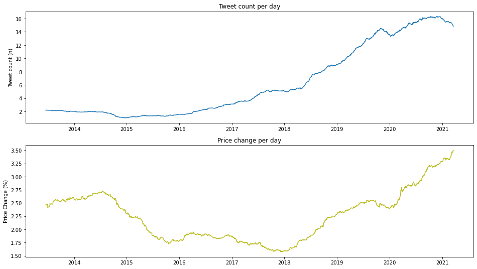

```python
mavg365['date'] = pd.DataFrame(np.array(df.date)[364:])

plt.figure(figsize = [16,9])

plt.subplot(2,1,1)
plt.errorbar(x = mavg365['date'], y = mavg365['tweet'], label = 'Tweets', color = sb.color_palette()[0])
plt.title('Tweet count per day')
plt.ylabel('Tweet count (n)')

plt.subplot(2,1,2)
plt.errorbar(x = mavg365['date'], y = mavg365['price_change'], label = 'Price Change(%)', color = sb.color_palette()[8])
plt.title('Price change per day')
plt.ylabel('Price Change (%)')


plt.show()
```